# Lecture Code: Regression Graphics

Engineering Statistics I (MA223)

While the “Coding Cookbook” on the course site gives an overview of all code covered in the class, this document provides the code that accompanies the lecture centering on graphics within regression.

## Background

Large surveys are commonly conducted to inform policy decisions. The Study on the Efficacy of Nosocomial Infection Control (SENIC Project) was to determine whether infection surveillance and control programs have have reduced the rates of nosocomial (hospital-acquired) infection in the United States hospitals. This data set consists of a random sample of 113 hospitals selected from across the US. Each record corresponds to information on hospital performance. The dataset consists of the following variables:

- ID: Unique hospital identifier.
- Length of Stay: Average length of stay of all patients in hospital (days).
- Age: Average age of patients (in years)
- Infection Risk: Average estimated probability of acquiring infection in hospital (percent).
- Routine Culturing Ratio: Ratio of number of cultures performed to the number of patients without signs or symptoms of hospital-acquired infection, times 100.
- Routine Xray Ratio: Ratio of number of X-rays performed to number of patients without signs or symptoms of pneumonia, times 100.
- Number of Beds: Average number of beds in hospital during study period.
- Medical School: Indicator of whether the hospital is associated with a medical school (1 = Yes, 2 = No).
- Region: Indicator of the geographic region for hospital (1 = NE, 2 = NC, 3 = S, 4 = W).
- Average Census: Average number of patients per day in hospital during study period.
- Number Nurses: Average number of full-time equivalent registered and licensed practical nurses during study period (number of full time plus one half the number of part time).
- Available Facilities: Percent of 35 potential facilities and services that are provided by the hospital.

A subset of the data is shown below.

| ID | Length of Stay | Age | Infection Risk | Routine Culturing Ratio | Routine Xray Ratio | Number of Beds | Medical School | Region | Average Census | Number Nurses | Available Facilities |
| --- | --- | --- | --- | --- | --- | --- | --- | --- | --- | --- | --- |
| 1 | 7.13 | 55.7 | 4.1 | 9.0 | 39.6 | 279 | 2 | 4 | 207 | 241 | 60.0 |
| 2 | 8.82 | 58.2 | 1.6 | 3.8 | 51.7 | 80 | 2 | 2 | 51 | 52 | 40.0 |
| 3 | 8.34 | 56.9 | 2.7 | 8.1 | 74.0 | 107 | 2 | 3 | 82 | 54 | 20.0 |
| 4 | 8.95 | 53.7 | 5.6 | 18.9 | 122.8 | 147 | 2 | 4 | 53 | 148 | 40.0 |
| 5 | 11.20 | 56.5 | 5.7 | 34.5 | 88.9 | 180 | 2 | 1 | 134 | 151 | 40.0 |
| 6 | 9.76 | 50.9 | 5.1 | 21.9 | 97.0 | 150 | 2 | 2 | 147 | 106 | 40.0 |
| 7 | 9.68 | 57.8 | 4.6 | 16.7 | 79.0 | 186 | 2 | 3 | 151 | 129 | 40.0 |
| 8 | 11.18 | 45.7 | 5.4 | 60.5 | 85.8 | 640 | 1 | 2 | 399 | 360 | 60.0 |
| 9 | 8.67 | 48.2 | 4.3 | 24.4 | 90.8 | 182 | 2 | 3 | 130 | 118 | 40.0 |
| 10 | 8.84 | 56.3 | 6.3 | 29.6 | 82.6 | 85 | 2 | 1 | 59 | 66 | 40.0 |

[output cut: 103 more lines]

## Questions

We will consider the following three questions:

1. Overall, is the infection risk within a hospital associated with the typical length of stay for a patient at the hospital?
2. After taking into account the typical length of stay, is the infection risk within a hospital different for those associated with a medical school?
3. Is the relationship between the infection risk within a hospital and the typical length of stay different within various regions of the country?

## Correlation

Consider the first question. Suppose we wanted to examine, overall, the relationship between these two variables. This can be accomplished easily with a scatterplot comparing the two variables.

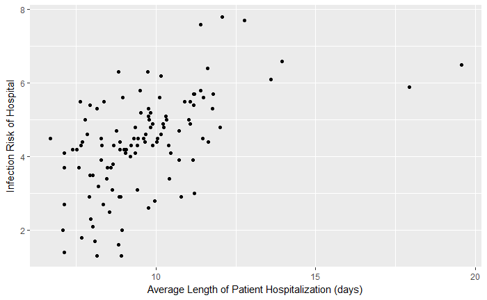

```r
qplot(data = senic,
      y = `Infection Risk`,
      x = `Length of Stay`,
      xlab = "Average Length of Patient Hospitalization (days)",
      ylab = "Infection Risk of Hospital")
```

The graphic shows the overall relationship, but we would like to quantify this relationship. The correlation coefficient summarizes two things:

- The *direction* of the linear relationship between two quantitative variables.
- The *strength* of the linear relationship between two quantitative variables.

```r
senic %>%
  summarise(Cor_LengthOfStay = cor(`Infection Risk`, `Length of Stay`),
            Cor_Age = cor(`Infection Risk`, Age))
```

| Cor_LengthOfStay | Cor_Age |
| --- | --- |
| 0.5334438 | 0.001093166 |

## Graphics

Graphically examining relationships with more than two variables requires us to make use of color and other aesthetics.

- After taking into account the typical length of stay, is the infection risk within a hospital different for those associated with a medical school?

Our first attemt might look something like the following:

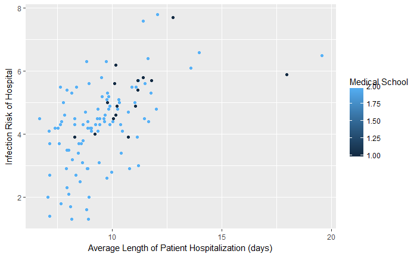

```r
qplot(data = senic,
      y = `Infection Risk`,
      x = `Length of Stay`,
      color = `Medical School`,
      xlab = "Average Length of Patient Hospitalization (days)",
      ylab = "Infection Risk of Hospital")
```

This graphic allows us to answer the question, but there is something off about the scale that we see in the graphic. We know that there are only two ways to answer this question, but it looks like we could answer 1.5 for medical school affiliation. The issue here is that the variable is being treated as a number. Of course, the program does not know that this is not really the case. So, we need to communicate two things: first, that the variable is categorical and second that these values actually represent something.

```r
senic <- senic %>%
  mutate(`Medical School` = recode(`Medical School`,
                                   `1` = "Affiliated with Medical School",
                                   `2` = "Not Affiliated with Medical School"))
```

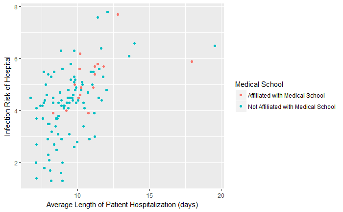

```r
qplot(data = senic,
      y = `Infection Risk`,
      x = `Length of Stay`,
      color = `Medical School`,
      xlab = "Average Length of Patient Hospitalization (days)",
      ylab = "Infection Risk of Hospital")
```

The new graphic communicates the same information, but is a bit cleaner.

What about our last question:

- Is the relationship between the infection risk within a hospital and the typical length of stay different within various regions of the country?

We can begin the same way, a graphic with color for the various regions. Again, we need to first be sure that it is coded correctly.

```r
senic <- senic %>%
  mutate(Region = recode(Region,
                         `1` = "Northeast",
                         `2` = "Northcentral",
                         `3` = "South",
                         `4` = "West"))
```

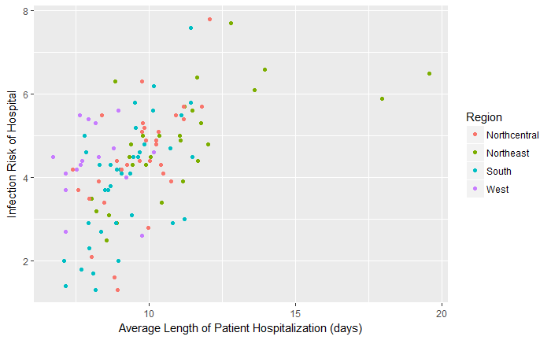

```r
qplot(data = senic,
      y = `Infection Risk`,
      x = `Length of Stay`,
      color = Region,
      xlab = "Average Length of Patient Hospitalization (days)",
      ylab = "Infection Risk of Hospital")
```

This is helpful, but we can make it better. Notice the question is whether the overall relationship (the trajectory) is the same within each color. To get at this, we can add a smoothing line to get a feel for the relationship.

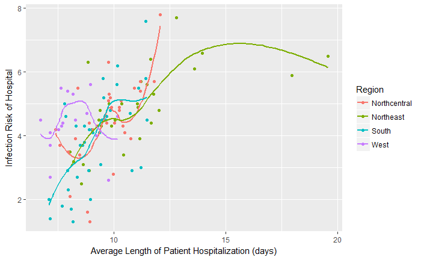

```r
qplot(data = senic,
      y = `Infection Risk`,
      x = `Length of Stay`,
      color = Region,
      geom = c("point", "smooth"),
      se = FALSE,
      xlab = "Average Length of Patient Hospitalization (days)",
      ylab = "Infection Risk of Hospital")
```

We want to be careful not to over-interpret this plot. However, we can see that roughly things look the same except for in the West. That curve tends to behave quite a bit differently. Again, we do not overinterpret this graphic, but it can help showcase a bit of what is happening.